# Project - Data Exploration - Week 8 (remove rows with missing data)

Troy McSimov

2023-10-10

## 1. How many breweries are present in each state?

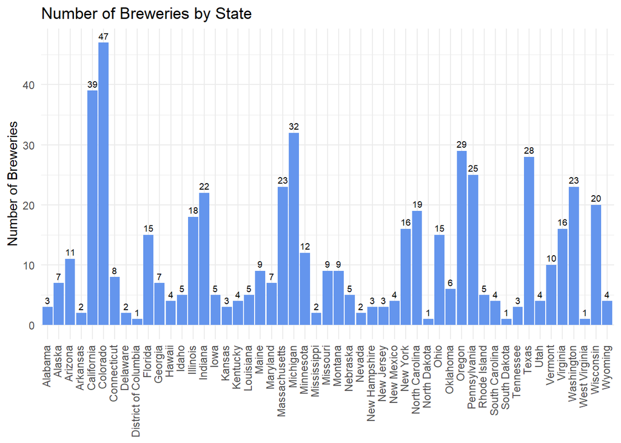

```r
# Create a table of state counts
byState <- table(breweries$State)

# Convert the table to a data frame
byState_df <- as.data.frame(byState)

# Rename the columns and trim whitespace around state abbreviations
colnames(byState_df) <- c("abb", "Breweries")
byState_df$abb <- str_trim(byState_df$abb)

# Create a lookup table for state abbreviation to state name (and add DC as District of Columbia)
lookup = data.frame(abb = state.abb, State = state.name)
lookup <- rbind(lookup,data.frame(abb = "DC", State = "District of Columbia"))

# Add a new column with full state names to the data frame
byStateName <- merge(byState_df, lookup, by = "abb", all.x = TRUE)

# Create dataset with just State and Count of Breweries
subset_df <- byStateName[, c("State", "Breweries")]

# Plot number of breweries by State
ggplot(subset_df, aes(x = State, y = Breweries)) +
  geom_text(aes(label = Breweries), vjust = -0.5, size = 2.5) +
  geom_bar(stat = "identity", fill = "Cornflower Blue") +
  labs(y = "Number of Breweries", x = "State",
       title = "Number of Breweries by State") +
  theme_minimal() +
theme(axis.title.x=element_blank(),
        axis.text.x=element_text(angle=90, vjust = 0.25, hjust=1))  # Vertical x-axis labels
```

## 2. Merge beer data with the breweries data. Print the first 6 observations and the last six observations to check the merged file.

```r
# Rename beers$Brewery_id to beers$Brew_ID to make it easier to merge with brewery dataset
colnames(beers)[colnames(beers) == "Brewery_id"] <- "Brew_ID"

# Merge beers and breweries dataset on "Brew_ID" columns
brews <- left_join(beers, breweries, by = "Brew_ID")

# Data validation after merge
head(brews, n=6) # Looks okay
```

```
##                         Name.x Beer_ID   ABV IBU Brew_ID            Style
## 1      Abbey's Single (2015- )    2505 0.049  22      58 Abbey Single Ale
## 2 Abbey's Single Ale (Current)    1887 0.049  22      58 Abbey Single Ale
## 3                Alaskan Amber    1920 0.053  18     271          Altbier
## 4        Altus Bohemes Altbier    1597 0.053  NA     365          Altbier
## 5        Main St. Virginia Ale    2377 0.050  40     123          Altbier
## 6        Main St. Virginia Ale    1248 0.050  40     123          Altbier
##   Ounces                              Name.y        City State
## 1     12                     Destihl Brewery Bloomington    IL
## 2     12                     Destihl Brewery Bloomington    IL
## 3     12             Alaskan Brewing Company      Juneau    AK
## 4     12                    Bohemian Brewery     Midvale    UT
## 5     12 Center of the Universe Brewing C...     Ashland    VA
## 6     12 Center of the Universe Brewing C...     Ashland    VA
```

```r
tail(brews, n=6) # Looks okay
```

```
##                              Name.x Beer_ID   ABV IBU Brew_ID        Style
## 2405          Wild Onion Summer Wit     398 0.042  13     362      Witbier
## 2406                Special Release    2210    NA  NA      30
## 2407 Kilt Lifter Scottish-Style Ale    1635 0.060  21     161 Scottish Ale
## 2408                  OktoberFiesta    2527 0.053  27      67       Marzen
## 2409                 The CROWLERâ„¢    1796    NA  27     167
## 2410           CAN'D AID Foundation    1790    NA  NA     167
##      Ounces                     Name.y            City State
## 2405     12 Wild Onion Brewing Company Lake Barrington    IL
## 2406     16        Cedar Creek Brewery    Seven Points    TX
## 2407     12 Four Peaks Brewing Company           Tempe    AZ
## 2408     12   Freetail Brewing Company     San Antonio    TX
## 2409     32        Oskar Blues Brewery        Longmont    CO
## 2410     12        Oskar Blues Brewery        Longmont    CO
```

## 3. Address the missing values in each column.

### There were only 17 beers missing ABV after we updated the beers_updated_2.csv file with research done on the Internet (sources provided in Beers_analysis.xlsx). Because this is such a small number of beers, we have decided to remove these beers from the dataset. Along with this update, we also changed the missing IBU values to 0 for ‘Ciders’, ‘Low Alcohol Beer’, and ‘Shandys’ as they usually contain little to zero IBU.

### For the remaining 944 beers with missing IBUs we took the median IBU for each Style of beer and used imputation to replace the missing values with the medians of the respective Style to preserve these records. Based on our research, each Style of beer had a narrow range of IBUs often seen in beers within that classification. For that reason we felt it necessary to take the median of each Style over the median of all beers seen in this dataset.

```r
# There are only 17 beers missing ABV, these will be removed given the small amount
filtered_brews <- brews[!is.na(brews$ABV), ]

# Create dataset of just rows with null IBU to further investigate in correlation in these missing values
nulls <- filtered_brews[is.na(brews$IBU), ]

# Observe counts of unique values in each column to determine if any correlation might be identified of the 969 rows missing IBUs
#table(nulls['ABV']) # no correlation seen when compared to full dataset
#table(nulls['Ounces']) # no correlation seen when compared to full dataset
#table(nulls['Style']) # no correlation seen when compared to full dataset
#table(nulls['Name.y']) # no correlation seen when compared to full dataset
#table(nulls['City']) # no correlation seen when compared to full dataset
#table(nulls['State']) # no correlation seen when compared to full dataset

# Get median IBU of each Style
IBU_lookup <- filtered_brews %>%
  group_by(Style) %>%
  summarise(
    median_IBU_Style = median(IBU, na.rm = TRUE)
  )

# Create new column in brews to include median IBU for each style
# Loop through each row in filtered_brews
for(i in 1:nrow(filtered_brews)){
  if(is.na(filtered_brews$IBU[i])){
    filtered_brews$IBU[i] <- IBU_lookup$median_IBU_Style[IBU_lookup$Style == filtered_brews$Style[i]]
  }
}

# There are still 11 beers missing IBU due to no available median value for their particular class, these will be removed
filtered_brews <- filtered_brews[!is.na(filtered_brews$IBU), ]
```

## 4. Compute the median alcohol content and international bitterness unit for each state. Plot a bar chart to compare.

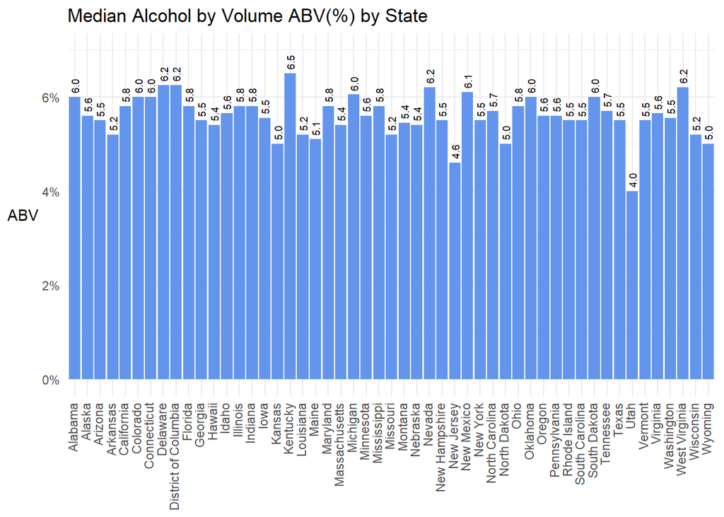

```r
# Get median of ABV and IBU by State
median_result <- filtered_brews %>%
  group_by(State) %>%
  summarise(
    median_ABV = median(ABV, na.rm = TRUE),
    median_IBU = median(IBU, na.rm = TRUE)
  )

# Reorganize column names and merge State name into table
colnames(median_result) <- c("abb", "ABV", "IBU")
median_result$abb <- str_trim(median_result$abb)
median_result <- merge(median_result, lookup, by = "abb", all.x = TRUE)
median_result <- median_result[, c("State", "ABV", "IBU")]

# Find the row with the highest median ABV and IBU
ABV_row_number <- which(median_result$ABV == max(median_result$ABV))
IBU_row_number <- which(median_result$IBU == max(median_result$IBU))

# Print the result with the highest median ABV by State highlighted in yellow and the highest median IBU by State highlighted in pink
#knitr::kable(median_result, format="html", caption = "Median ABV and IBU by State") %>% #kable_styling(full_width = FALSE, position = "center", latex_options = "scale_down") %>% #row_spec(ABV_row_number, background = "yellow") %>% row_spec(IBU_row_number, background = "pink")

# Plot bar chart showing median ABV for each state order by ABV desc
ggplot(median_result, aes(x = State, y = ABV)) +
  geom_text(aes(label = format(ABV*100, digits=2)), angle = 90, hjust = -0.25, size = 2.5) +
  geom_bar(stat = "identity", fill = "Cornflower Blue") +
  labs(y = "ABV", x = "State",
       title = "Median Alcohol by Volume ABV(%) by State") +
  theme_minimal() + scale_y_continuous(labels=percent, limits = c(0,0.07)) +
  theme(axis.title.x=element_blank(), axis.title.y = element_text(angle = 0, vjust = 0.5),
        axis.text.x=element_text(angle=90, vjust = 0.25, hjust=1))
```

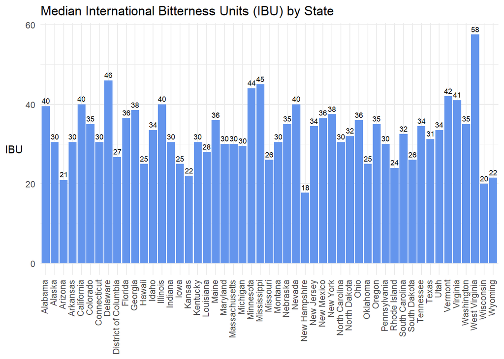

```r
# Plot bar chart showing median IBU for each state order by IBU desc
ggplot(median_result, aes(x = State, y = IBU)) +
  geom_text(aes(label = format(IBU, digits=2)), vjust = -0.5, size = 2.5) +
  geom_bar(stat = "identity", fill = "Cornflower Blue") +
  labs(y = "IBU", x = "State",
       title = "Median International Bitterness Units (IBU) by State") +
  theme_minimal() +
theme(axis.title.x=element_blank(), axis.title.y = element_text(angle = 0, vjust = 0.5),
        axis.text.x=element_text(angle=90, vjust = 0.25, hjust=1))  # Vertical x-axis labels
```

## 5. Which state has the maximum alcoholic (ABV) beer? Which state has the most bitter (IBU) beer?

```r
max_ABV <- which(filtered_brews$ABV == max(filtered_brews$ABV))
max_IBU <- which(filtered_brews$IBU == max(filtered_brews$IBU))
filtered_brews[max_ABV, ]
```

```
##                                                    Name.x Beer_ID   ABV IBU
## 2172 Lee Hill Series Vol. 5 - Belgian Style Quadrupel Ale    2565 0.128  24
##      Brew_ID            Style Ounces                  Name.y    City State
## 2172      52 Quadrupel (Quad)   19.2 Upslope Brewing Company Boulder    CO
```

```r
filtered_brews[max_IBU, ]
```

```
##                        Name.x Beer_ID   ABV IBU Brew_ID
## 427 Bitter Bitch Imperial IPA     980 0.082 138     375
##                              Style Ounces                  Name.y    City State
## 427 American Double / Imperial IPA     12 Astoria Brewing Company Astoria    OR
```

## 6. Comment on the summary statistics and distribution of the ABV variable.

### The ABV data appears to have a normal distribution with a slight right skewness.

```r
summary(filtered_brews$ABV)
```

```
##    Min. 1st Qu.  Median    Mean 3rd Qu.    Max.
## 0.00100 0.05000 0.05600 0.05966 0.06700 0.12800
```

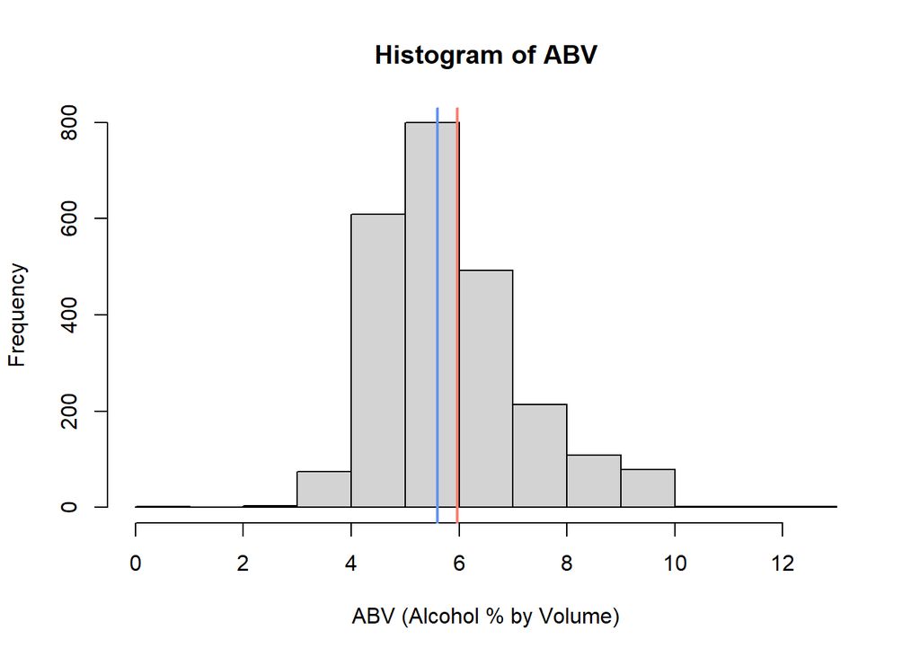

```r
hist(filtered_brews$ABV*100, xlab = "ABV (Alcohol % by Volume)", main = "Histogram of ABV")

abline(v = median(filtered_brews$ABV)*100, col = "Cornflower blue", lwd = 2)
abline(v = mean(filtered_brews$ABV)*100, col = "Salmon", lwd = 2)
```

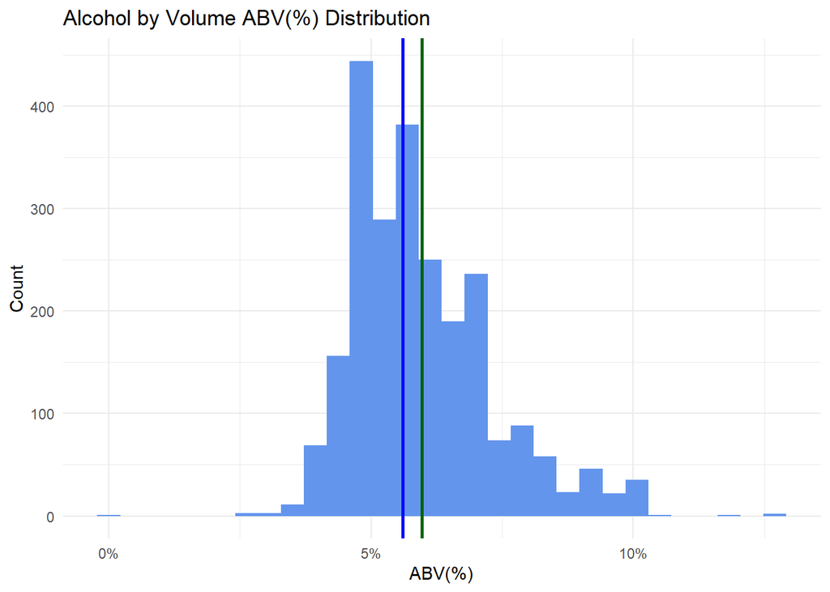

```r
ggplot(filtered_brews, aes(x = ABV)) +
  geom_histogram(fill = "Cornflower Blue") +
  labs(x = "ABV(%)", y = "Count",
       title = "Alcohol by Volume ABV(%) Distribution") +
  theme_minimal() + scale_x_continuous(labels=percent) + geom_vline(xintercept = median(filtered_brews$ABV), color = "blue", size = 1) + geom_vline(xintercept = mean(filtered_brews$ABV), color = "dark green", size = 1)
```

## 7. Is there an apparent relationship between the bitterness of the beer and its alcoholic content? Draw a scatter plot. Make your best judgment of a relationship and EXPLAIN your answer.

### The amount of alcohol by volume in a beer does not explicitly increase the bitterness, however, adding more malt, and therefore more sugar, to beer to increase the amount of alcohol can offset the bitterness. Based on this dataset, there appears to be a relationship of ABV to IBU data showing the as the % of alcohol by volume seen, so do we see an increase in international bitterness units.

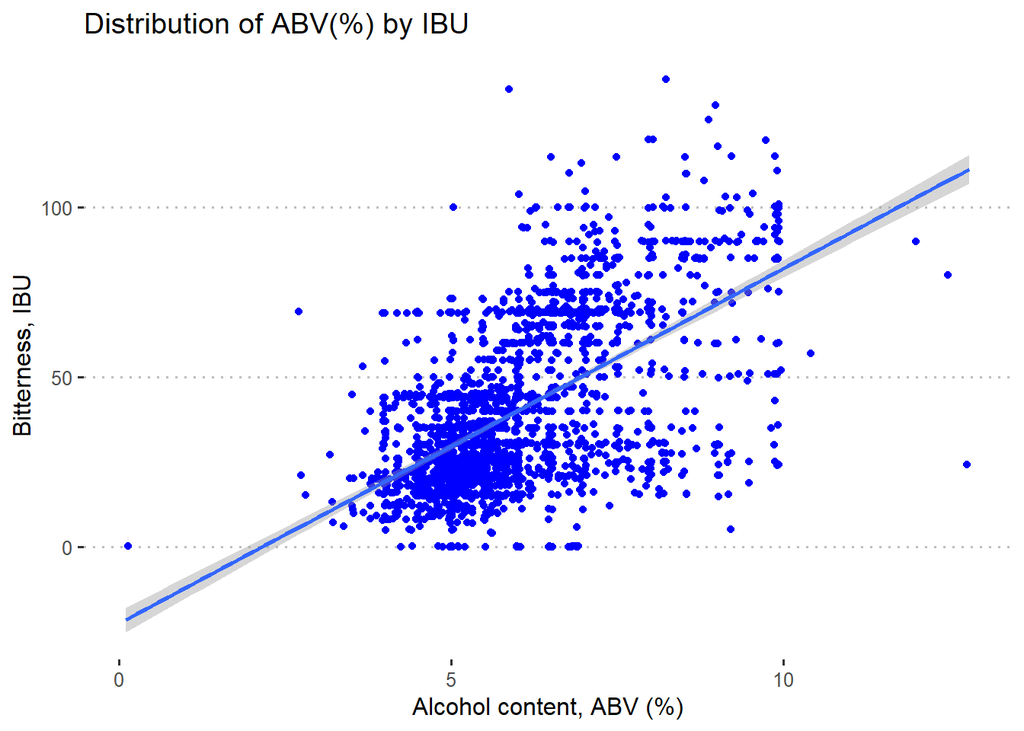

```r
ggplot(data = filtered_brews, mapping = aes(x = ABV*100, y = IBU)) + geom_jitter(color="blue") + theme_pubclean() + xlab("Alcohol content, ABV (%)") + ylab ("Bitterness, IBU") + ggtitle ("Distribution of ABV(%) by IBU") + geom_smooth(method = "lm")
```